# R markdown lab

Jeff Leek

July 3, 2015

1. Try compiling this document using the “Knit HTML” button. What files are produced?
2. Edit the output to be “pdf_document” and recompile. What files are produced?
3. Edit the output to be “word_document” and recompile. What files are produced?
4. What does the label “chunk1” do in the following code chunk?

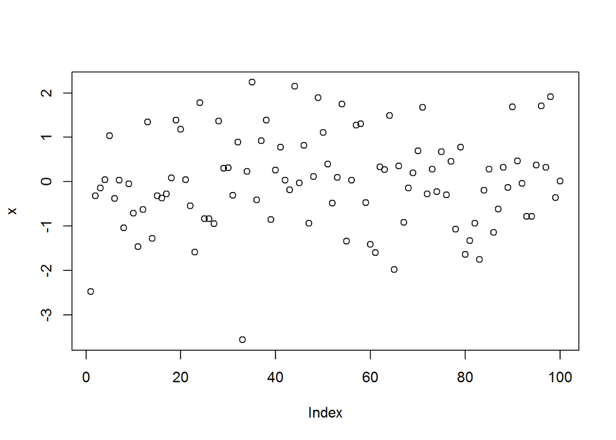

```r
x = rnorm(100)
plot(x)
```

# This is a primary header. Add a secondary header with ## on the line below and recompile.

5. Change fig.height to something larger/smaller and see what happens

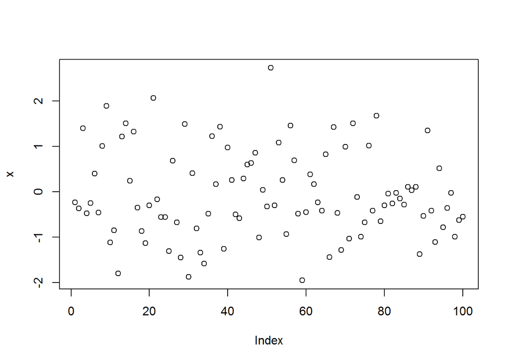

```r
x = rnorm(100)
plot(x)
```

6. Add a chunk option of fig.align=“center” to center this plot

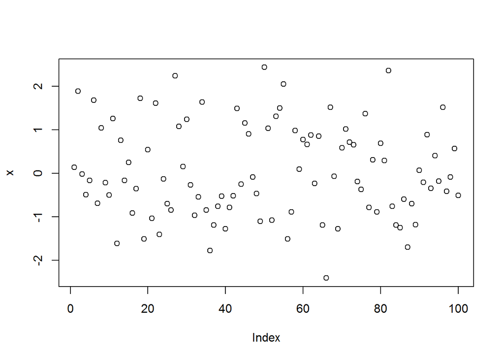

```r
x = rnorm(100)
plot(x)
```

7. Add a chunk option of echo=FALSE and see what happens

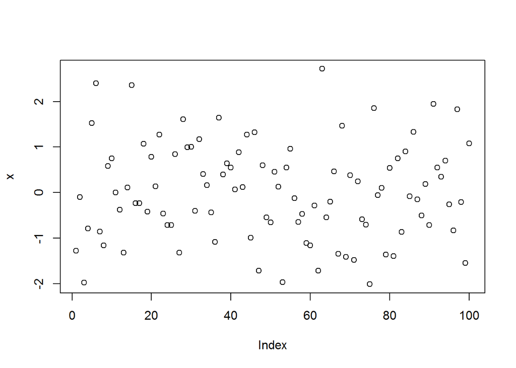

```r
x = rnorm(100)
plot(x)
```

8. Uncomment this code and recompile the document. Then add a chunk command cache=TRUE and recompile. What files are created? Try compiling one more time.

```r
#Sys.sleep(10)
```

9. Check out the docs at: http://rmarkdown.rstudio.com/ and look under formats. See if you can create and compile an R markdown presentation.
10. Add the command devtools::session_info() to this chunk and look at the output